# Praca domowa 3 - Techniki Wizualizacji Danych

Michał Tomczyk 313520

## Wprowadzenie

W moim eksperymencie sprawdzę czy wykresy kołowe faktycznie utrudniają odczytywanie wartości i porównywanie która z nich jest większa. W tym celu utoworzyłem ręcznie ramkę z sześcioma wartościami liczbowymi, przypisanymi do kolejnych liter alfabetu A-F.

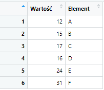

Ramka danych

W zamyśle chciałem mieć dwa elementy mające różne, ale zbliżone do siebie wartości i porównać czy łatwiej jest stwierdzić który element jest większy patrząc na wykres kołowy czy słupkowy (tymi ekementami są B oraz D, dodatkowo oddzielone elementem C też posiadającym zbliżoną wartość). Stworzyłem więc wyżej wymienione wykresy dla swojej przykładowej ramki:

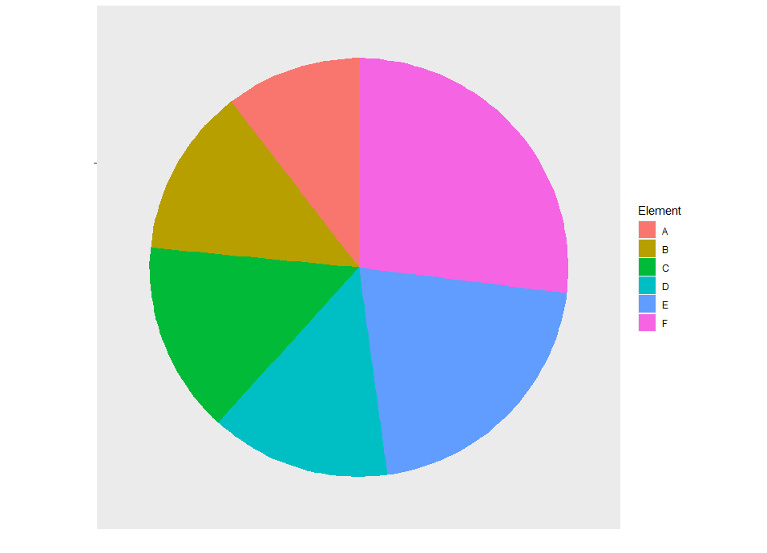

Wykres kołowy

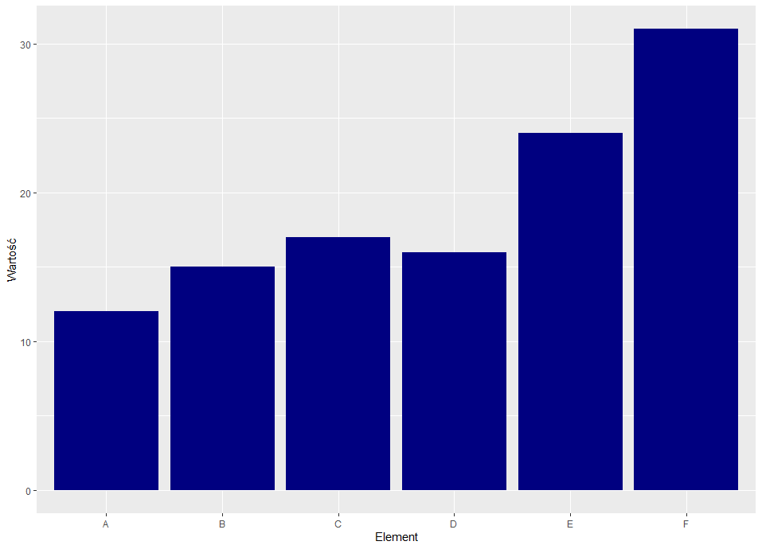

Wykres słupkowy

## Przeproawdzenie eksperymantu

W celu stwierdzenia który z wykresów ułatwia porównywanie wielkości wartości przeprowadziłem ankietę za pomocą Google Forms. W ankiecie najpierw umieściłem wykres kołowy i poprosiłem użytkownika o stwierdzenie, czy wartość B jest większa od D, czy D jest większa od B, czy są one sobie równe. Następnie pokazałem wykres słupkowy i zadałem to samo pytanie. W założeniu porównanie wartości na wykresie kołowym miało być trudne, a po spojrzeniu na wykres słupkowy odpowiadający miał nabrać pewności, że element D faktycznie jest większy.

## Wyniki

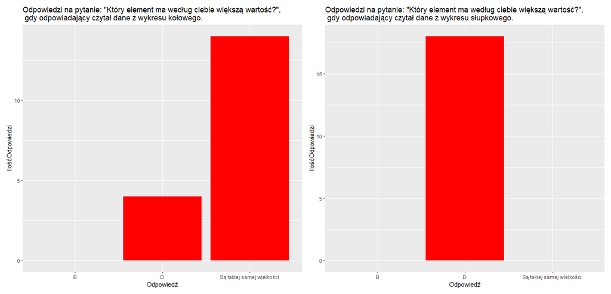

przedstawienie wyników